# Managing sleep records files

Paul Bouchequet

Records of physiological signals during sleep can take many forms. It starts with simple accelerometry [1] and goes up to full polysomnography (PSG) [2], a simultaneous recording of more than ten physiological signals. But sleep records all share a common aspect: they are timeseries, collections of datapoints indexed in time order. Along these timeseries are found metadata: recording conditions, patient information, sample rates and such.

The European Data Format (EDF) has been firstly described in 1992 to ease medical timeseries storage and exchange [3]. Primarily conceived to store polygraphic signals, the design has been updated in 2003 to support events data, thus renaming the format to EDF+ [4]. Another update in 2013 implemented video storage [5]. A small website recaps history and lists a few databases, softwares and users of the EDF format: http://edfplus.info/.

Since its publication, the EDF imposed itself as a standard for exchange of sleep records. Files size come from few hundred megabytes to a few gigabytes, accoring to the number, length and resolution of signals.

# Reading EDF Records files

An example EDF file can be donwloaded using the following code:

```r
download.file("https://osf.io/57j2u/download", "15012016HD.edf")
```

This night has been recorded at the Sleep and Vigilance center of the Hôtel-Dieu, Paris, France. To read EDF files, we can use the R library [`edfReader`](https://CRAN.R-project.org/package=edfReader). Reading an EDF file takes two steps: First reading the headers, then reading the signals. Signals can be filtered to read only the needed data.

```r
library(edfReader)

h <- readEdfHeader("15012016HD.edf")

s <- readEdfSignals(h, signals = c("C3-M2", "ECG"))
```

The variable `s` now contains signals and their metadata in a convenient list object. For instance, the electroencephalographic (EEG) derivation `C3-M2` signal and sample rate can be accessed like this:

```r
c3m2 <- s$`C3-M2`$signal

c3m2sr <- s$`C3-M2`$sRate
```

Plotting seconds 30 to 60 of the record would look like this:

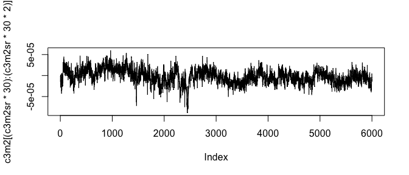

```r
plot(c3m2[(c3m2sr*30):(c3m2sr*30*2)],type = "l")
```

# Events Files

While the EDF standard supports events since 2003, very few software allow events exportation directly in EDF files.

Scoring of the previous sample record can be downloaded here.

```r
download.file("https://osf.io/h4ysj/download", "15012016HD.csv")
```

These events have been exported from Noxturnal, a sleep scoring software published by Resmed [6]. As they are stored using a particular convention, the `read_events_noxturnal` from the `rsleep` package helps us reading the file as clean dataframe.

```r
library(rsleep)

events <- read_events_noxturnal("15012016HD.csv")

summary(events)
```

```
#>      begin                          end
#>  Min.   :2016-01-15 22:30:15   Min.   :2016-01-15 22:30:15
#>  1st Qu.:2016-01-16 01:33:07   1st Qu.:2016-01-16 01:33:37
#>  Median :2016-01-16 04:40:56   Median :2016-01-16 04:41:02
#>  Mean   :2016-01-16 04:38:24   Mean   :2016-01-16 04:38:53
#>  3rd Qu.:2016-01-16 07:41:52   3rd Qu.:2016-01-16 07:42:22
#>  Max.   :2016-01-16 10:46:00   Max.   :2016-01-16 10:46:30
#>     event
#>  Length:1586
#>  Class :character
#>  Mode  :character
#>
#>
#>
```

```r
unique(events$event)
```

```
#> [1] "Début de l'analyse" "Notification"       "AWA"
#> [4] "Micro-éveil"        "N1"                 "N2"
#> [7] "N3"                 "Avertissement"      "REM"
```

Using events dataframe containing sleep stage scoring, `rsleep` can plot hypnograms.

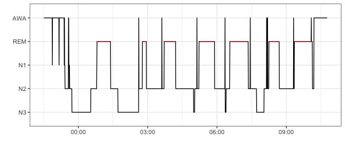

```r
plot_hypnogram(events)
```

# Morpheo Data Format Records

Although EDF imposed itself as a standard for data exchange, it may not be seen as suitable for all of the usages. When finding new ways to store physiological data, one must keep in mind some simple rule to ensure its effectiveness:

- **Simplicity**: Data format definitions must be straightforward, understadable by non-IT population to lower technical barriers in using the format.
- **Interoperability**: Data must be able to be read and wrote easily on every platform, using any programming language. This implies format definitions must be published and open sourced while respecting several standards.
- **Efficiency**: A good data format must not slow down operations with costly read and write operations.
- **Scalability**: Usages of today are not the usages of tomorrow. 20 years ago, it was not common to compare thousands of PSGs in a single analysis. But big data democratization lowered costs and made it possible. Who knows the data usages in 20 years?

Following these recommendations, a consortium of public and private research teams published in 2018 the implementation a new format: the Morpheo Data Format (MDF) [7]. The MDF format does not aim to replace EDF as a standard for data exchange. This format have been designed to ease simultaneous work and collaboration over records stored on disk while ensuring interoperability,

MDF distinguishes *signal* data from *events* and *metadata*:

- **Signals** regroup all the physiological, high sample rate timeseries such as electroencephalography, electrocardiography, nasal flow, oxygen levels, and so on.
- **Metadata**, as its name suggests, is data about the record. Patient identifier, recording conditions and all fields describing the record are considered metadata.
- **Events** include sleep scoring and technical events such as equipment logs.

In MDF, signals are stored as raw binary files in folders, while events and metadata are stored in JSON. This way, any programming language can read MDF file without the use of complex dependencies.

## Writing MDF files

MDF files can be wrote from EDF files and events using the `write_mdf` function from `rsleep`.

```r
write_mdf(edfPath = "15012016HD.edf",
          mdfPath = "15012016HD",
          channels = c("C3-M2","ECG"),
          events = events)
```

This call creates the directory `15012016HD`. Events are stored in the `events.json` file. Record metadata is in the `metadata.json` file. For each channel a directory is created, with `signal.bin` containing the raw signal and `metadata.json` the metadata.

MDF files can be read using the `read_mdf` function from `rsleep`.

```r
mdf <- read_mdf("15012016HD")
```

`read_mdf` quickly reads the record as list. Signals and metadata can be accessed in the same way as the EDF file.

For instance, 10 seconds of ECG signal would look like this:

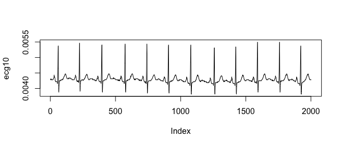

```r
ecgSrate <- mdf$channels$ECG$metadata$sRate

ecg10 <- mdf$channels$`ECG`$signal[(50*ecgSrate):(60*ecgSrate)]

plot(ecg10, type="l")
```

# References

[1] V.T. van Hees, S. Sabia, S.E. Jones, A.R. Wood, K.N. Anderson, M. Kivimäki, T.M. Frayling, A.I. Pack, M. Bucan, M.I. Trenell, D.R. Mazzotti, P.R. Gehrman, B.A. Singh-Manoux, M.N. Weedon, Estimating sleep parameters using an accelerometer without sleep diary, Scientific Reports. 8 (2018). doi:10.1038/s41598-018-31266-z.

[2] AASM Scoring Manual - American Academy of Sleep Medicine, American Academy of Sleep Medicine Association for Sleep Clinicians and Researchers. (n.d.). https://aasm.org/clinical-resources/scoring-manual/.

[3] B. Kemp, A. Värri, A.C. Rosa, K.D. Nielsen, J. Gade, A simple format for exchange of digitized polygraphic recordings, Electroencephalography and Clinical Neurophysiology. 82 (1992) 391–393. doi:10.1016/0013-4694(92)90009-7.

[4] B. Kemp, J. Olivan, European data format ’plus’ (EDF+), an EDF alike standard format for the exchange of physiological data, Clinical Neurophysiology. 114 (2003) 1755–1761. doi:10.1016/S1388-2457(03)00123-8.

[5] B. Kemp, M. Roessen, European data format now supports video, Sleep. 36 (2013) 1111. doi:10.5665/sleep.2822.

[6] ResMed, (n.d.). https://www.resmed.com/.

[7] P. Bouchequet, D. Jin, G. Solelhac, M. Chennaoui, D. Leger, Morpheo Data Format (MDF), un nouveau format de données simple, robuste et performant pour stocker et analyser les enregistrements de sommeil, Médecine Du Sommeil. 15 (2018) 48–49. doi:10.1016/j.msom.2018.01.130.